# May NO2 Data Analysis - Panels by Station

Henry Perillo

6/23/2020

# Data Input

First, library the necessary packages:

```r
# Clear working environment
rm(list = ls())

# Load Packages
library(dplyr)
library(plyr)
library(readr)
library(Hmisc)
library(psych)
library(rmweather)
library(ranger)
library(hexbin)
library(tidyr)
library(stringr)
library(ggplot2)
library(data.table)
library(lubridate)
library(Rmisc)
library(knitr)
```

Call file:

```r
# Set working directory
setwd("~/Desktop/Research_Project/Data/AQ/Final_Data")

# Load data from master file
no2 <- read_csv('NO2.csv')
```

Edit dataframe:

```r
# We're left with a dataframe containing hourly NO2 values for
# every day of 2018. Now, let's isolate the columns of interest.
no2 <- no2[,-3]
NO2 <- no2 %>%
        gather("Rathmines", "Winetavern Street", "Dun Laoghaire", key = 'Station', value = 'value')

# We can now convert the date and time column to a timestamp
# format so we can use it with the rmweather package. Also,
# we'll create year, day, hour, and month columns to house
# that data individually should we choose to break up the
# master dataframe later.
NO2$date <- dmy_hm(NO2$date)

# Create Year, Month, Date, and Hour columns.
NO2 <- NO2 %>%
  mutate(Year = str_sub(date,3,4),
         Month = str_sub(date,6,7),
         Date = str_sub(date,9,10),
         Hour = str_sub (date, 12, 13))

# We'll make all of our data numerical:
NO2 <- NO2 %>%
  mutate(value = as.numeric(value))
```

The result is a cleaner dataframe that holds hourly meteorlogical and air quality data at three monitoring stations in the GDA from 2017 to 2020.

Create linear dataframe:

```r
# Use rmweather to create a dataframe with 'weekday' column
NO2 <- NO2 %>%
  rmw_prepare_data(na.rm = TRUE)

# Remove negative values
NO2 <- NO2 %>%
  filter(value >= 0)

# Make 'Month' data numerical
NO2$Month <- as.numeric(NO2$Month)

# Filter months
COVID_Linear <- NO2%>%
  filter(Month < 7)

# Create new dataframe with summary values for each variable
COVID_Linear_Daily <- summarySE(COVID_Linear, measurevar= "value", groupvars=c('Station', "Month", "Year", 'Date'))

# Add an ID column for weeks to enable gtrouping later
COVID_Linear_Daily <- COVID_Linear_Daily %>%
  mutate(Week = case_when(
    Date >= '01' & Date <= '07' ~ 1,
    Date >= '08' & Date <= '14' ~ 2,
    Date >= '15' & Date <= '21'  ~ 3,
    Date >= '22' & Date <= '31' ~ 4))
```

Examine monthly averages:

```r
# Create monthly summary dataframe
Monthly_Avgs_NO2 <- summarySE(COVID_Linear_Daily, measurevar= "value", groupvars=c('Station', "Month", "Year"))

# Make month column numerical
Monthly_Avgs_NO2$Month <- as.numeric(Monthly_Avgs_NO2$Month)

# Isolate May
May_Monthly_Avgs_NO2 <- Monthly_Avgs_NO2 %>%
  filter(Month == 5)
```

Check the residuals for normality:

```r
# Create the residuals dataframe:
no2$date <- dmy_hm(no2$date)

# We'll make all of our data numerical:
no2 <- no2 %>%
  mutate(Rathmines = as.numeric(Rathmines),
         `Dun Laoghaire` = as.numeric(`Dun Laoghaire`),
         `Winetavern Street` = as.numeric(`Winetavern Street`))

# Remove NA values
no2 <- no2[!is.na(no2$Rathmines), ]
no2 <- no2[!is.na(no2$`Winetavern Street`), ]
no2 <- no2[!is.na(no2$`Dun Laoghaire`), ]

# Remove negative values
no2 <- no2 %>%
  filter(Rathmines >= 0,
         `Winetavern Street` >= 0,
         `Dun Laoghaire` >= 0)

# Create Year, Month, Date, and Hour columns.
no2 <- no2 %>%
  mutate(Year = str_sub(date,3,4),
         Month = str_sub(date,6,7),
         Date = str_sub(date,9,10),
         Hour = str_sub (date, 12, 13))

May_NO2 <- no2 %>%
  filter(Month == '05')
```

Residuals for Rathmines:

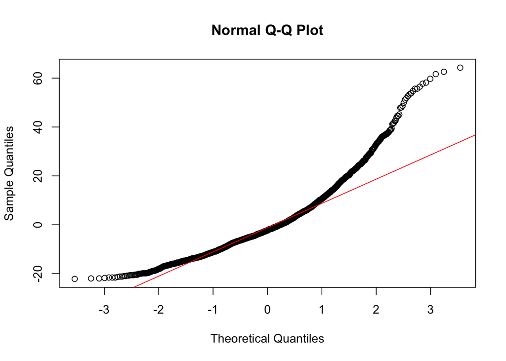

```r
# Build the linear model
May_Rath_NO2.lm <- lm(Rathmines ~ Year, data = May_NO2)

# Create a QQ plot of residuals
qqnorm(residuals(May_Rath_NO2.lm))
qqline(residuals(May_Rath_NO2.lm), col = "red")
```

```r
# Shapiro-wilk test
shapiro.test(residuals(May_Rath_NO2.lm))
```

```
##
##  Shapiro-Wilk normality test
##
## data:  residuals(May_Rath_NO2.lm)
## W = 0.91555, p-value < 2.2e-16
```

Residuals for Winetavern Street

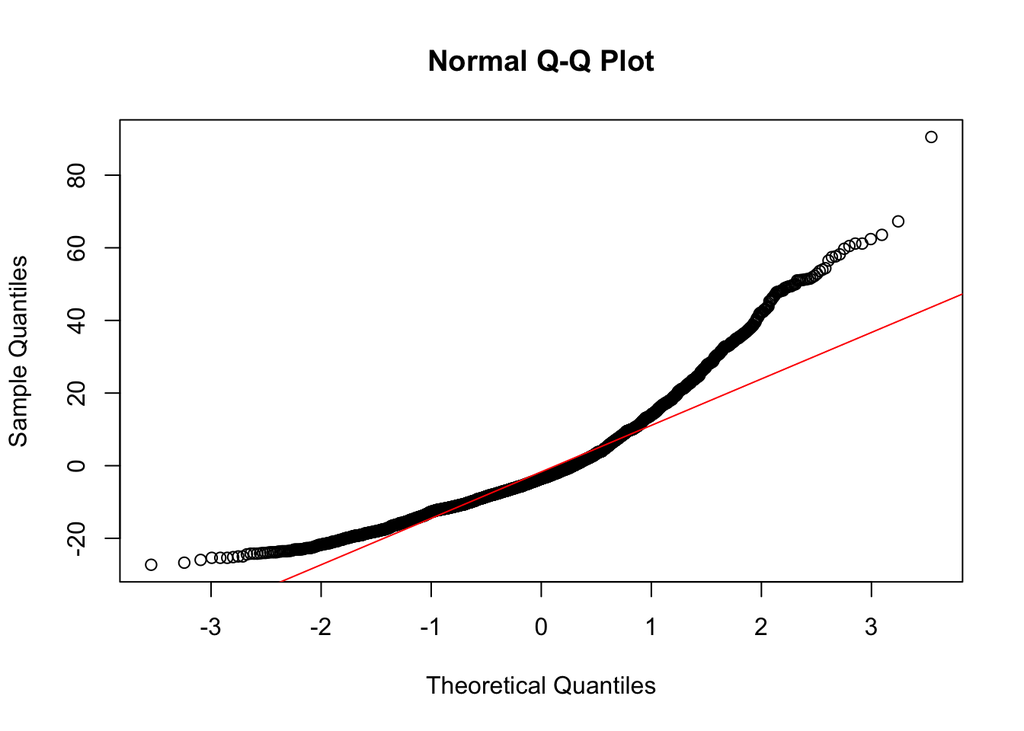

```r
# Build the linear model
May_Wine_NO2.lm <- lm(`Winetavern Street` ~ Year, data = May_NO2)

# Create a QQ plot of residuals
qqnorm(residuals(May_Wine_NO2.lm))
qqline(residuals(May_Wine_NO2.lm), col = "red")
```

```r
# Shapiro-wilk test
shapiro.test(residuals(May_Wine_NO2.lm))
```

```
##
##  Shapiro-Wilk normality test
##
## data:  residuals(May_Wine_NO2.lm)
## W = 0.91061, p-value < 2.2e-16
```

Residuals for Dun Laoghaire

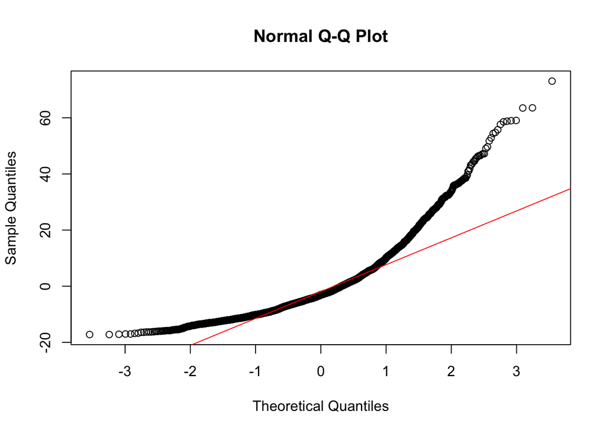

```r
# Build the linear model
May_Dun_NO2.lm <- lm(`Dun Laoghaire` ~ Year, data = May_NO2)

# Create a QQ plot of residuals
qqnorm(residuals(May_Dun_NO2.lm))
qqline(residuals(May_Dun_NO2.lm), col = "red")
```

```r
# Shapiro-wilk test
shapiro.test(residuals(May_Dun_NO2.lm))
```

```
##
##  Shapiro-Wilk normality test
##
## data:  residuals(May_Dun_NO2.lm)
## W = 0.85741, p-value < 2.2e-16
```

## Monthly

May monthly multiplot:

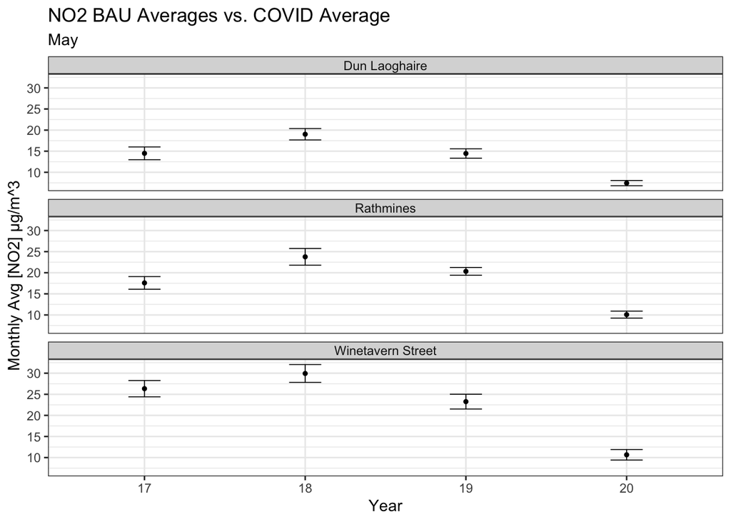

```r
# Barplot
May_Monthly_NO2_plot <- ggplot(May_Monthly_Avgs_NO2, aes(x=Year, y=value)) +
  geom_point(stat="identity",
             size=1) +      # Thinner lines
  geom_errorbar(aes(ymin=value-se, ymax=value+se),
                size=.3,    # Thinner lines
                width=.2,
                position=position_dodge(.9)) +
  labs(x = 'Year',
       y = 'Monthly Avg [NO2] µg/m^3',
       color = "Year",
       title = "NO2 BAU Averages vs. COVID Average",
       subtitle = "May") +
  theme_bw()+
  facet_wrap(~ Station, dir = 'v')+
  theme(
    strip.text.x = element_text(margin = margin(2, 0, 2, 0)))
May_Monthly_NO2_plot
```

Create separate dataframes for each monitoring station:

```r
# Dataframe by station
Rath_Monthly_Avgs_May_NO2 <- COVID_Linear_Daily %>%
  filter(Station == "Rathmines",
         Month == 5)
Dun_Monthly_Avgs_May_NO2 <- COVID_Linear_Daily %>%
  filter(Station == "Dun Laoghaire",
         Month == 5)
Wine_Monthly_Avgs_May_NO2 <- COVID_Linear_Daily %>%
  filter(Station == "Winetavern Street",
         Month == 5)

# Kruskall-wallis test for Rathmines
May_Rath.w <- kruskal.test(value ~ Year, data = Rath_Monthly_Avgs_May_NO2)
pairwise.wilcox.test(Rath_Monthly_Avgs_May_NO2$value, Rath_Monthly_Avgs_May_NO2$Year,
                 p.adjust.method = "BH")
```

```
##
##  Pairwise comparisons using Wilcoxon rank sum test
##
## data:  Rath_Monthly_Avgs_May_NO2$value and Rath_Monthly_Avgs_May_NO2$Year
##
##    17      18      19
## 18 0.01654 -       -
## 19 0.07298 0.22235 -
## 20 0.00011 7.5e-09 1.2e-10
##
## P value adjustment method: BH
```

```r
# Kruskall-wallis test for Winetavern Street
May_Wine.w <- kruskal.test(value ~ Year, data = Wine_Monthly_Avgs_May_NO2)
pairwise.wilcox.test(Wine_Monthly_Avgs_May_NO2$value, Wine_Monthly_Avgs_May_NO2$Year,
                 p.adjust.method = "BH")
```

```
##
##  Pairwise comparisons using Wilcoxon rank sum test
##
## data:  Wine_Monthly_Avgs_May_NO2$value and Wine_Monthly_Avgs_May_NO2$Year
##
##    17      18      19
## 18 0.322   -       -
## 19 0.393   0.057   -
## 20 5.9e-09 1.4e-11 5.5e-07
##
## P value adjustment method: BH
```

```r
# Kruskall-wallis test for Dun laoghaire
May_Dun.w <- kruskal.test(value ~ Year, data = Dun_Monthly_Avgs_May_NO2)
pairwise.wilcox.test(Dun_Monthly_Avgs_May_NO2$value, Dun_Monthly_Avgs_May_NO2$Year,
                 p.adjust.method = "BH")
```

```
##
##  Pairwise comparisons using Wilcoxon rank sum test
##
## data:  Dun_Monthly_Avgs_May_NO2$value and Dun_Monthly_Avgs_May_NO2$Year
##
##    17      18      19
## 18 0.05696 -       -
## 19 1.00000 0.02410 -
## 20 0.00022 3.3e-11 3.8e-06
##
## P value adjustment method: BH
```

## Weekly

Weekly dataframe:

```r
# Summary dataframe
Weekly_Avgs_NO2 <- summarySE(COVID_Linear_Daily, measurevar= "value", groupvars=c('Station', "Month", "Week", "Year"))

# Make the 'Week' column numerical
Weekly_Avgs_NO2$Week <- as.numeric(Weekly_Avgs_NO2$Week)

# Filter by month
May_Weekly_Avgs_NO2 <- Weekly_Avgs_NO2 %>%
  filter(Month == 5)
```

May weekly multiplot:

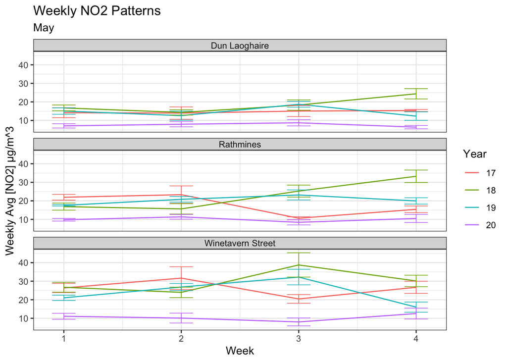

```r
# Line plot for weeks
May_Weekly_NO2_plot <- ggplot(data = May_Weekly_Avgs_NO2, aes(x = Week, y = value)) +
  geom_line(aes(color = Year)) +
  geom_errorbar(aes(ymin=value-se, ymax=value+se, color = Year),
                size=.3,    # Thinner lines
                width=.2) +
  labs(x = 'Week',
       y = 'Weekly Avg [NO2] µg/m^3',
       color = "Year",
       title = "Weekly NO2 Patterns",
       subtitle = "May")+
  facet_wrap(~ Station, dir = 'v')+
  theme_bw()+
  theme(
    strip.text.x = element_text(margin = margin(2, 0, 2, 0))
  )
May_Weekly_NO2_plot
```

## Daily

Daily averages:

```r
# Filter by month
May_Daily_Avgs_NO2 <- COVID_Linear_Daily %>%
  filter(Month == 5)

# Make 'Date' column numeric
May_Daily_Avgs_NO2$Date <- as.numeric(May_Daily_Avgs_NO2$Date)
```

Daily multiplot:

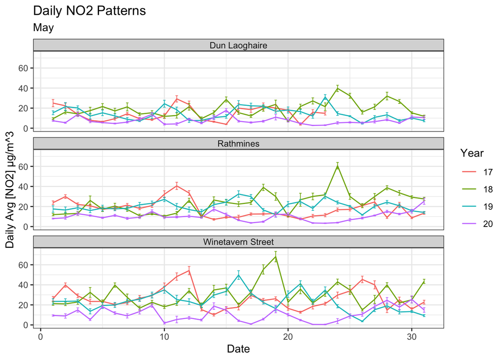

```r
# Line plot for days
May_Daily_NO2_plot <- ggplot(data = May_Daily_Avgs_NO2, aes(x = Date, y = value)) +
  geom_line(aes(color = Year)) +
  geom_errorbar(aes(ymin=value-se, ymax=value+se, color = Year),
                size=.3,    # Thinner lines
                width=.2)+
  labs(x = 'Date',
       y = 'Daily Avg [NO2] µg/m^3',
       color = "Year",
       title = "Daily NO2 Patterns",
       subtitle = "May")+
  facet_wrap(~ Station, dir = 'v')+
  theme_bw()+
  theme(
    strip.text.x = element_text(margin = margin(2, 0, 2, 0))
  )
May_Daily_NO2_plot
```

## Diurnal Analysis

Diurnal weekday analysis:

```r
# Create weekday dataframe
COVID_Linear_weekday <- COVID_Linear %>%
  filter(weekday >= 1,
         weekday < 6)

# Remove NA values
COVID_Linear_weekday <- COVID_Linear_weekday[!is.na(COVID_Linear_weekday$value), ]

# Remove negative values
COVID_Linear_weekday <- COVID_Linear_weekday %>%
  filter(value >= 0)

# Make 'Year' column a factor
COVID_Linear_weekday$Year <- as.factor(COVID_Linear_weekday$Year)

# Create the two-year average values to compare to the COVID experimental period value.
COVID_Linear_weekday <- COVID_Linear_weekday %>%
  mutate(Period = case_when(
    Year == '19'| Year =='18' | Year == '17' ~ '2017-2019',
    Year == '20' ~ '2020'))
```

Diurnal weekday averages by year:

```r
# Weekday summary dataframe
Weekday_Diurnal_Avgs_NO2 <- summarySE(COVID_Linear_weekday, measurevar= "value", groupvars=c('Station', "Year", "Month", "Hour" ))

# Make 'Year' column a factor
Weekday_Diurnal_Avgs_NO2$Year <- as.factor(Weekday_Diurnal_Avgs_NO2$Year)

# Isolate May
May_weekday_Diurnal_Avgs_NO2 <- Weekday_Diurnal_Avgs_NO2 %>%
  filter(Month == 5)
```

Diurnal May multiplot weekday:

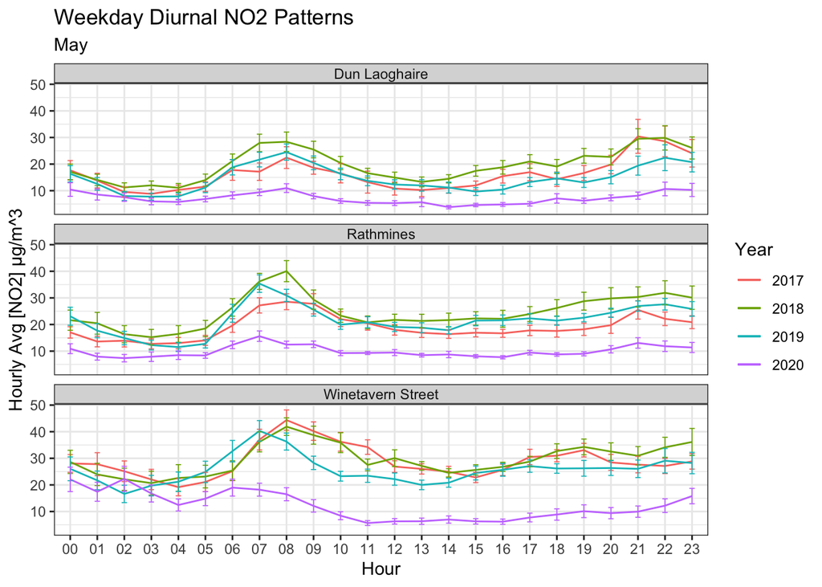

```r
# Create separate dataframes for each year
May_weekday_Diurnal_Avgs_NO2_17 <- May_weekday_Diurnal_Avgs_NO2 %>%
  filter(Year == '17')
May_weekday_Diurnal_Avgs_NO2_18 <- May_weekday_Diurnal_Avgs_NO2 %>%
  filter(Year == '18')
May_weekday_Diurnal_Avgs_NO2_19 <- May_weekday_Diurnal_Avgs_NO2 %>%
  filter(Year == '19')
May_weekday_Diurnal_Avgs_NO2_20 <- May_weekday_Diurnal_Avgs_NO2 %>%
  filter(Year == '20')

# Merge dataframes together
May_weekday_Diurnal_Avgs_NO2_17_20 <- cbind(May_weekday_Diurnal_Avgs_NO2_17, May_weekday_Diurnal_Avgs_NO2_18, May_weekday_Diurnal_Avgs_NO2_19,May_weekday_Diurnal_Avgs_NO2_20)
May_weekday_Diurnal_Avgs_NO2_17_20 <- May_weekday_Diurnal_Avgs_NO2_17_20[,-c(10:14, 19:23, 28:32)]

# Line plot of diurnal patterns by year
May_weekday_Diurnal_NO2_plot <- ggplot(data = May_weekday_Diurnal_Avgs_NO2_17_20, aes(Hour)) +
  geom_line(aes(y = value, group = 1, colour = "2017")) +
  geom_line(aes(y = value.1, group = 1, colour = "2018")) +
  geom_line(aes(y = value.2, group = 1, colour = "2019")) +
  geom_line(aes(y = value.3, group = 1, colour = "2020")) +
  geom_errorbar(aes(ymin=value-se, ymax=value+se, colour = "2017"),
                size=.3,    # Thinner lines
                width=.2,
                position=position_dodge(.9)) +
  geom_errorbar(aes(ymin=value.1-se.1, ymax=value.1+se.1, colour = "2018"),
                size=.3,    # Thinner lines
                width=.2,
                position=position_dodge(.9)) +
  geom_errorbar(aes(ymin=value.2-se.2,
                    ymax=value.2+se.2, colour = "2019"),
                size=.3,    # Thinner lines
                width=.2,
                position=position_dodge(.9)) +
  geom_errorbar(aes(ymin=value.3-se.3, ymax=value.3+se.3, colour = "2020"),
                size=.3,    # Thinner lines
                width=.2,
                position=position_dodge(.9)) +
  labs(x = 'Hour',
       y = 'Hourly Avg [NO2] µg/m^3',
       color = "Year",
       title = "Weekday Diurnal NO2 Patterns",
       subtitle = "May")+
  facet_wrap(~ Station, dir = 'v')+
  theme_bw()+
  theme(
    strip.text.x = element_text(margin = margin(2, 0, 2, 0))
  )
May_weekday_Diurnal_NO2_plot
```

Diurnal weekday averages by period:

```r
# Weekday summary dataframe
Weekday_period_Diurnal_Avgs_NO2 <- summarySE(COVID_Linear_weekday, measurevar= "value", groupvars=c('Station', "Period", "Month", "Hour" ))

# Make 'Year' column a factor
Weekday_period_Diurnal_Avgs_NO2$Period <- as.factor(Weekday_period_Diurnal_Avgs_NO2$Period)

# Separate May
May_Weekday_period_Diurnal_Avgs_NO2 <- Weekday_period_Diurnal_Avgs_NO2 %>%
  filter(Month == 5)
```

Diurnal May multiplot weekday:

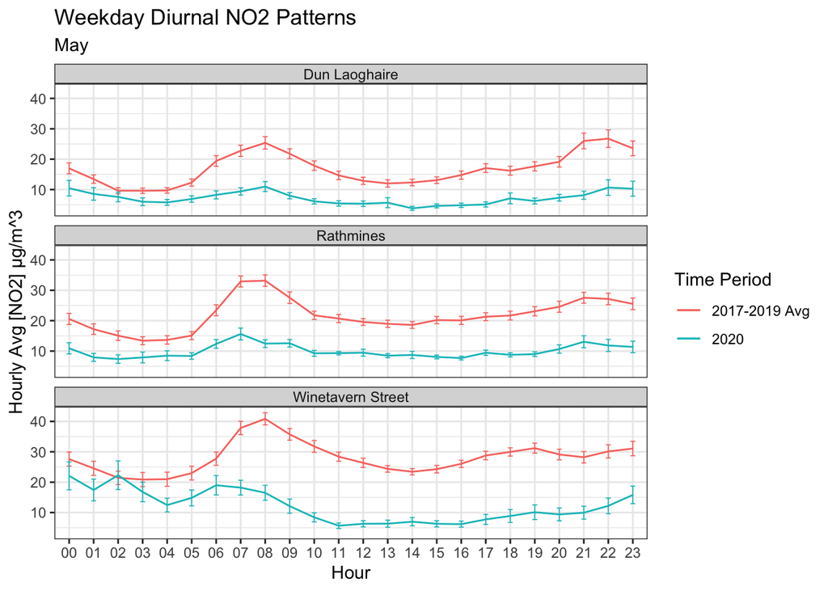

```r
# Create separate dataframes for each period
May_Weekday_period_Diurnal_Avgs_NO2_17_19 <- May_Weekday_period_Diurnal_Avgs_NO2 %>%
  filter(Period == '2017-2019')
May_Weekday_period_Diurnal_Avgs_NO2_20 <- May_Weekday_period_Diurnal_Avgs_NO2 %>%
  filter(Period == '2020')

# Merge dataframes together
May_Weekday_period_Diurnal_Avgs_NO2_17_20 <- cbind(May_Weekday_period_Diurnal_Avgs_NO2_17_19,May_Weekday_period_Diurnal_Avgs_NO2_20)

May_Weekday_period_Diurnal_Avgs_NO2_17_20 <- May_Weekday_period_Diurnal_Avgs_NO2_17_20[,-c(10:14)]

# Line plot of diurnal patterns by time period
May_Weekday_period_Diurnal_NO2_plot <- ggplot(data = May_Weekday_period_Diurnal_Avgs_NO2_17_20, aes(Hour)) +
  geom_line(aes(y = value, group = 1, colour = "2017-2019 Avg")) +
  geom_line(aes(y = value.1, group = 1, colour = "2020")) +
  geom_errorbar(aes(ymin=value-se, ymax=value+se, colour = "2017-2019 Avg"),
                size=.3,    # Thinner lines
                width=.2,
                position=position_dodge(.9)) +
  geom_errorbar(aes(ymin=value.1-se.1, ymax=value.1+se.1, colour = "2020"),
                size=.3,    # Thinner lines
                width=.2,
                position=position_dodge(.9)) +
  labs(x = 'Hour',
       y = 'Hourly Avg [NO2] µg/m^3',
       color = "Time Period",
       title = "Weekday Diurnal NO2 Patterns",
       subtitle = "May")+
  facet_wrap(~ Station, dir = 'v')+
  theme_bw()+
  theme(
    strip.text.x = element_text(margin = margin(2, 0, 2, 0))
  )
May_Weekday_period_Diurnal_NO2_plot
```

Diurnal weekend dataframe:

```r
# Create weekend dataframe
COVID_Linear_weekend <- COVID_Linear %>%
  filter(weekday >= 6,
         weekday <= 7)

# Remove NA values
COVID_Linear_weekend <- COVID_Linear_weekend[!is.na(COVID_Linear_weekend$value), ]

# Remove negative values
COVID_Linear_weekend <- COVID_Linear_weekend %>%
  filter(value >= 0)

COVID_Linear_weekend$Year <- as.factor(COVID_Linear_weekend$Year)

# Create the two-year average values to compare to the COVID experimental period value.
COVID_Linear_weekend <- COVID_Linear_weekend %>%
  mutate(Period = case_when(
    Year == '19'| Year =='18' | Year == '17' ~ '2017-2019',
    Year == '20' ~ '2020'))
```

Diurnal weekend Averages

```r
# Create summary dataframe
weekend_Diurnal_Avgs_NO2 <- summarySE(COVID_Linear_weekend, measurevar= "value", groupvars=c('Station', "Year", "Month", "Hour" ))

# Make 'Year' column a factor
weekend_Diurnal_Avgs_NO2$Year <- as.factor(weekend_Diurnal_Avgs_NO2$Year)

# Separate May
May_weekend_Diurnal_Avgs_NO2 <- weekend_Diurnal_Avgs_NO2 %>%
  filter(Month == 5)
```

Diurnal May multiplot weekend:

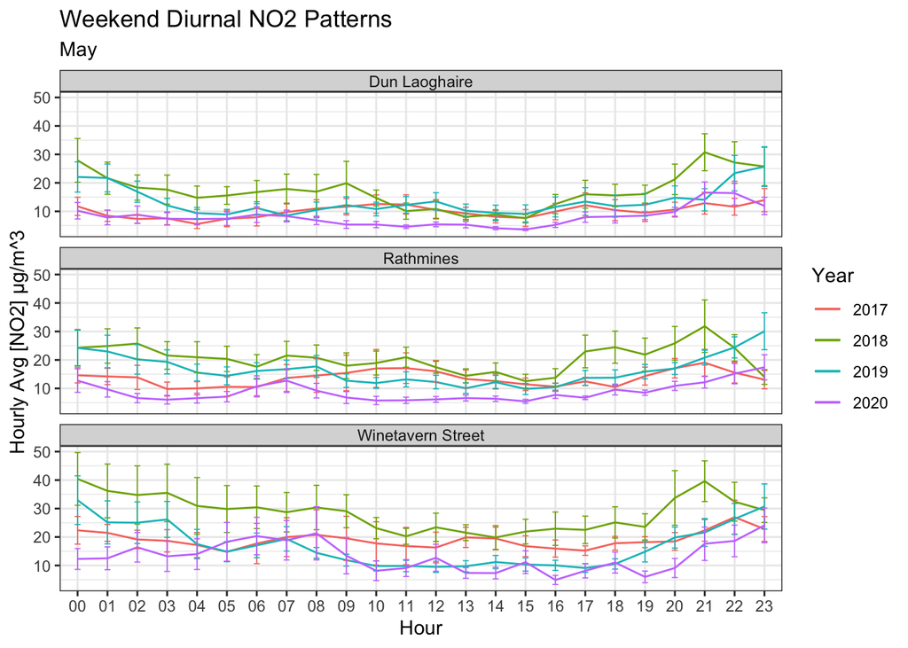

```r
# Create separate dataframes for each year
May_weekend_Diurnal_Avgs_NO2_17 <- May_weekend_Diurnal_Avgs_NO2 %>%
  filter(Year == '17')
May_weekend_Diurnal_Avgs_NO2_18 <- May_weekend_Diurnal_Avgs_NO2 %>%
  filter(Year == '18')
May_weekend_Diurnal_Avgs_NO2_19 <- May_weekend_Diurnal_Avgs_NO2 %>%
  filter(Year == '19')
May_weekend_Diurnal_Avgs_NO2_20 <- May_weekend_Diurnal_Avgs_NO2 %>%
  filter(Year == '20')

# Bind dataframes together
May_weekend_Diurnal_Avgs_NO2_17_20 <- cbind(May_weekend_Diurnal_Avgs_NO2_17, May_weekend_Diurnal_Avgs_NO2_18, May_weekend_Diurnal_Avgs_NO2_19,May_weekend_Diurnal_Avgs_NO2_20)

May_weekend_Diurnal_Avgs_NO2_17_20 <- May_weekend_Diurnal_Avgs_NO2_17_20[,-c(10:14, 19:23, 28:32)]

# Line plot of weekend averages
May_weekend_Diurnal_NO2_plot <- ggplot(data = May_weekend_Diurnal_Avgs_NO2_17_20, aes(Hour)) +
  geom_line(aes(y = value, group = 1, colour = "2017")) +
  geom_line(aes(y = value.1, group = 1, colour = "2018")) +
  geom_line(aes(y = value.2, group = 1, colour = "2019")) +
  geom_line(aes(y = value.3, group = 1, colour = "2020")) +
  geom_errorbar(aes(ymin=value-se, ymax=value+se, colour = "2017"),
                size=.3,    # Thinner lines
                width=.2,
                position=position_dodge(.9)) +
  geom_errorbar(aes(ymin=value.1-se.1, ymax=value.1+se.1, colour = "2018"),
                size=.3,    # Thinner lines
                width=.2,
                position=position_dodge(.9)) +
  geom_errorbar(aes(ymin=value.2-se.2,
                    ymax=value.2+se.2, colour = "2019"),
                size=.3,    # Thinner lines
                width=.2,
                position=position_dodge(.9)) +
  geom_errorbar(aes(ymin=value.3-se.3, ymax=value.3+se.3, colour = "2020"),
                size=.3,    # Thinner lines
                width=.2,
                position=position_dodge(.9)) +
  labs(x = 'Hour',
       y = 'Hourly Avg [NO2] µg/m^3',
       color = "Year",
       title = "Weekend Diurnal NO2 Patterns",
       subtitle = "May")+
  facet_wrap(~ Station, dir = 'v')+
  theme_bw()+
  theme(
    strip.text.x = element_text(margin = margin(2, 0, 2, 0))
  )
May_weekend_Diurnal_NO2_plot
```

Diurnal weekend averages by period:

```r
# Create weekend summary dataframe by period
weekend_period_Diurnal_Avgs_NO2 <- summarySE(COVID_Linear_weekend, measurevar= "value", groupvars=c('Station', "Period", "Month", "Hour" ))

# Make 'Period' a factor
weekend_period_Diurnal_Avgs_NO2$Period <- as.factor(weekend_period_Diurnal_Avgs_NO2$Period)

# Isolate May
May_weekend_period_Diurnal_Avgs_NO2 <- weekend_period_Diurnal_Avgs_NO2 %>%
  filter(Month == 5)
```

Diurnal May multiplot weekend:

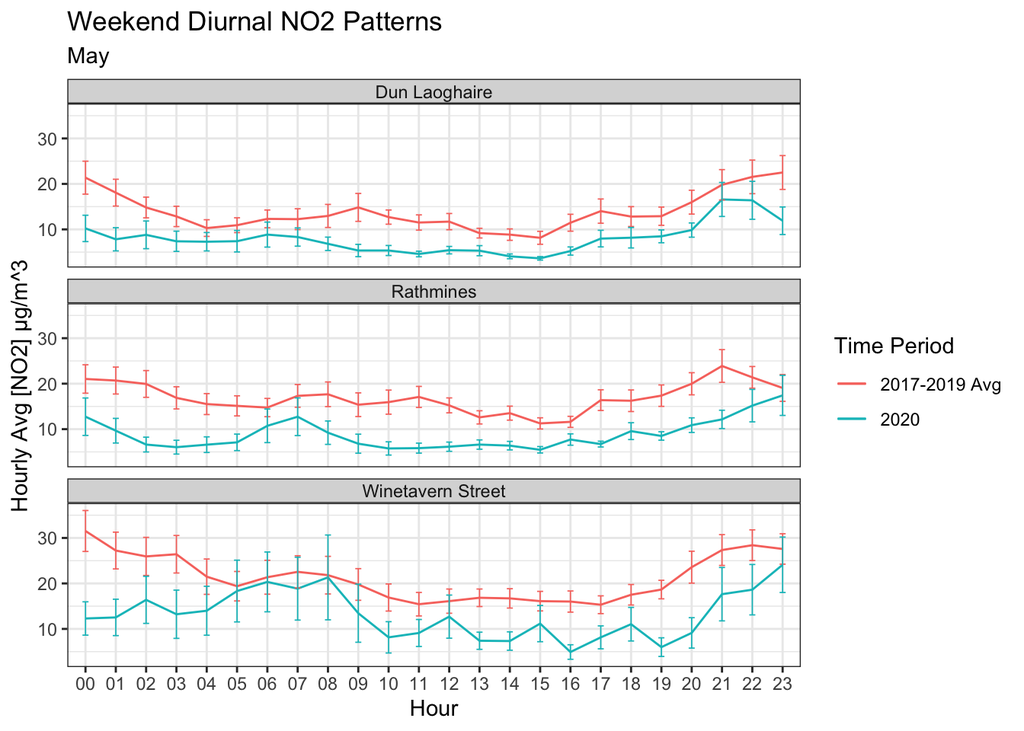

```r
# Create separate dataframes for each period
May_weekend_period_Diurnal_Avgs_NO2_17_19 <- May_weekend_period_Diurnal_Avgs_NO2 %>%
  filter(Period == '2017-2019')
May_weekend_period_Diurnal_Avgs_NO2_20 <- May_weekend_period_Diurnal_Avgs_NO2 %>%
  filter(Period == '2020')

# Bind dataframes together
May_weekend_period_Diurnal_Avgs_NO2_17_20 <- cbind(May_weekend_period_Diurnal_Avgs_NO2_17_19,May_weekend_period_Diurnal_Avgs_NO2_20)

May_weekend_period_Diurnal_Avgs_NO2_17_20 <- May_weekend_period_Diurnal_Avgs_NO2_17_20[,-c(10:14)]

# Create lineplot
May_weekend_period_Diurnal_NO2_plot <- ggplot(data = May_weekend_period_Diurnal_Avgs_NO2_17_20, aes(Hour)) +
  geom_line(aes(y = value, group = 1, colour = "2017-2019 Avg")) +
  geom_line(aes(y = value.1, group = 1, colour = "2020")) +
  geom_errorbar(aes(ymin=value-se, ymax=value+se, colour = "2017-2019 Avg"),
                size=.3,    # Thinner lines
                width=.2,
                position=position_dodge(.9)) +
  geom_errorbar(aes(ymin=value.1-se.1, ymax=value.1+se.1, colour = "2020"),
                size=.3,    # Thinner lines
                width=.2,
                position=position_dodge(.9)) +
  labs(x = 'Hour',
       y = 'Hourly Avg [NO2] µg/m^3',
       color = "Time Period",
       title = "Weekend Diurnal NO2 Patterns",
       subtitle = "May")+
  facet_wrap(~ Station, dir = 'v')+
  theme_bw()+
  theme(
    strip.text.x = element_text(margin = margin(2, 0, 2, 0))
  )
May_weekend_period_Diurnal_NO2_plot
```